# MovieLens Recommender System Capstone Project - Report

Alessandro Corradini - Harvard Data Science Professional

May 10, 2019

# Executive Summary

The purpose for this project is creating a recommender system using MovieLens dataset.

The version of movielens dataset used for this final assignment contains approximately 10 Milions of movies ratings, divided in 9 Milions for training and one Milion for validation. It is a small subset of a much larger (and famous) dataset with several millions of ratings. Into the training dataset there are approximately **70.000 users** and **11.000 different movies** divided in 20 genres such as Action, Adventure, Horror, Drama, Thriller and more.

After a initial data exploration, the recommender systems builted on this dataset are evaluated and choosen based on the RMSE - Root Mean Squared Error that should be at least lower than **0.87750**.

$$\mbox{RMSE} = \sqrt{\frac{1}{n}\sum_{t=1}^{n}e_t^2}$$

For accomplishing this goal, the **Regularized Movie+User+Genre Model** is capable to reach a RMSE of **0.8628**, that is really good.

# Exploratory Data Analysis

## Inital data Exploration

The 10 Millions dataset is divided into two dataset: `edx` for training purpose and `validation` for the validation phase.

The `edx` dataset contains approximately 9 Millions of rows with 70.000 different users and 11.000 movies with rating score between 0.5 and 5. There is no missing values (0 or NA).

**edx dataset**

| Users | Movies |
| --- | --- |
| 69878 | 10677 |

**Missing Values per Column**

|  | x |
| --- | --- |
| userId | 0 |
| movieId | 0 |
| rating | 0 |
| timestamp | 0 |
| title | 0 |
| genres | 0 |

The features/variables/columns in both datasets are six:

- **userId** `<integer>` that contains the unique identification number for each user.
- **movieId** `<numeric>` that contains the unique identification number for each movie.
- **rating** `<numeric>` that contains the rating of one movie by one user. Ratings are made on a 5-Star scale with half-star increments.
- **timestamp** `<integer>` that contains the timestamp for one specific rating provided by one user.
- **title** `<character>` that contains the title of each movie including the year of the release.
- **genres** `<character>` that contains a list of pipe-separated of genre of each movie.

**First 6 Rows of edx dataset**

| userId | movieId | rating | timestamp | title | genres |
| --- | --- | --- | --- | --- | --- |
| 1 | 122 | 5 | 838985046 | Boomerang (1992) | Comedy\|Romance |
| 1 | 185 | 5 | 838983525 | Net, The (1995) | Action\|Crime\|Thriller |
| 1 | 231 | 5 | 838983392 | Dumb & Dumber (1994) | Comedy |
| 1 | 292 | 5 | 838983421 | Outbreak (1995) | Action\|Drama\|Sci-Fi\|Thriller |
| 1 | 316 | 5 | 838983392 | Stargate (1994) | Action\|Adventure\|Sci-Fi |
| 1 | 329 | 5 | 838983392 | Star Trek: Generations (1994) | Action\|Adventure\|Drama\|Sci-Fi |

## Dataset Pre-Processing and Feature Engineering

After a initial data exploration, we notice that the `genres` are pipe-separated values. It’s necessary to extract them for more consisten, robust and precise estimate. We also observe that the `title` contains the year where the movie war released and this it could be necessary to predic the movie rating. Finally, we can extract the year and the month for each rating.

The pre-processing phase is composed by this steps:

1. Convert `timestamp` to a human readable date format;
2. Extract the month and the year from the date;
3. Extract the release year for each movie from the title;
4. Separate each genre from the pipe-separated value. It increases the size of both datasets.

After preprocessing the data, `edx` dataset looks like this:

**Processed edx datadaset**

| userId | movieId | rating | title | genre | release | yearOfRate | monthOfRate |
| --- | --- | --- | --- | --- | --- | --- | --- |
| 1 | 122 | 5 | Boomerang | Comedy | 1992 | 1996 | 8 |
| 1 | 122 | 5 | Boomerang | Romance | 1992 | 1996 | 8 |
| 1 | 185 | 5 | Net, The | Action | 1995 | 1996 | 8 |
| 1 | 185 | 5 | Net, The | Crime | 1995 | 1996 | 8 |
| 1 | 185 | 5 | Net, The | Thriller | 1995 | 1996 | 8 |
| 1 | 231 | 5 | Dumb & Dumber | Comedy | 1994 | 1996 | 8 |

## Rating Distribution

**Overview of Rating Distribution**

According to the histogram below, it shows that there are a small amount of negative votes (below 3). Maybe, the user tends to give a vote if he liked the movie. Half-Star votes are less common than “Full-Star” votes.

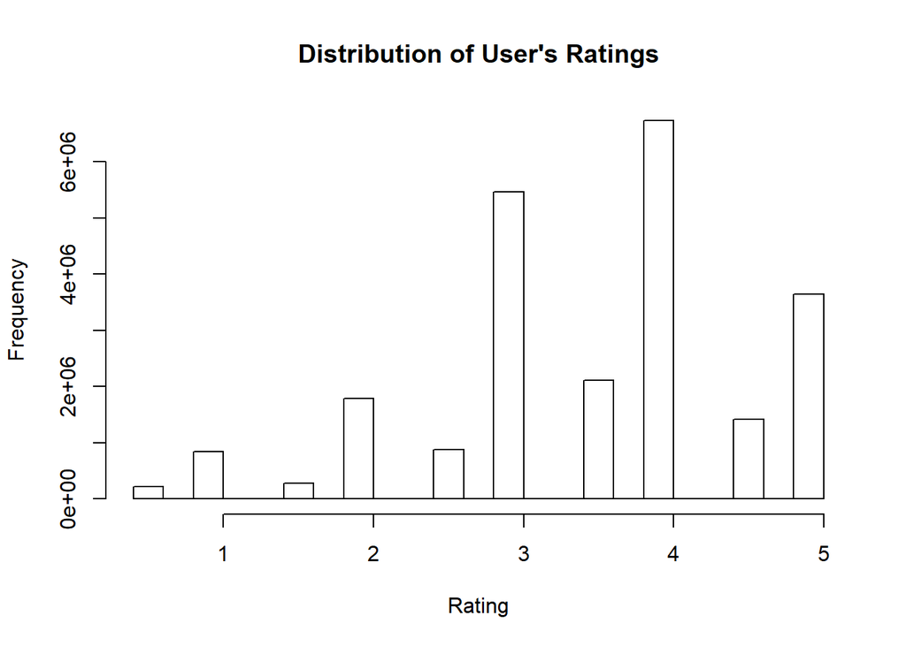

**Overview of Rating Frequency through Months and Years**

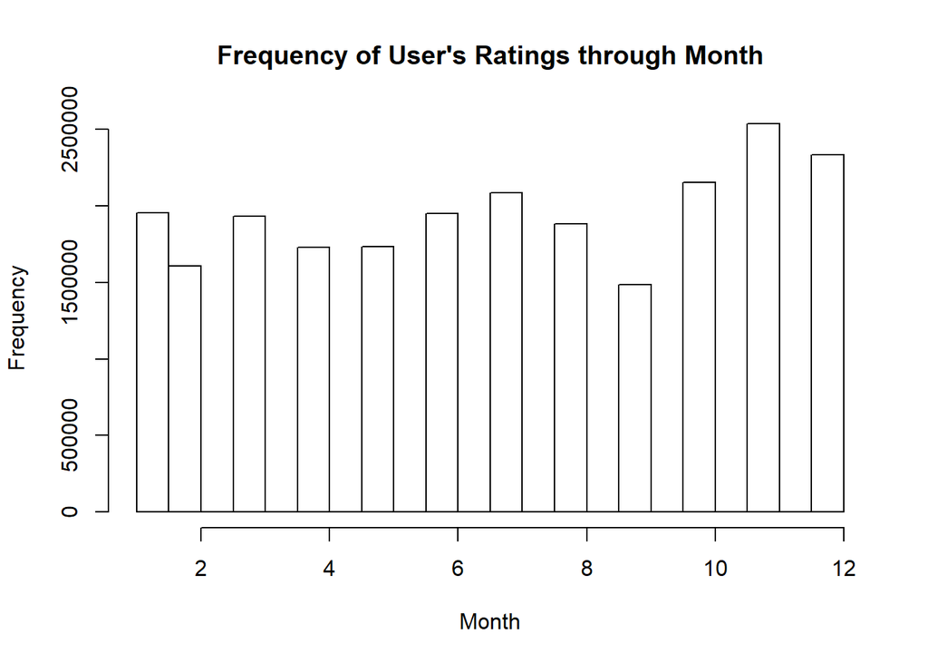

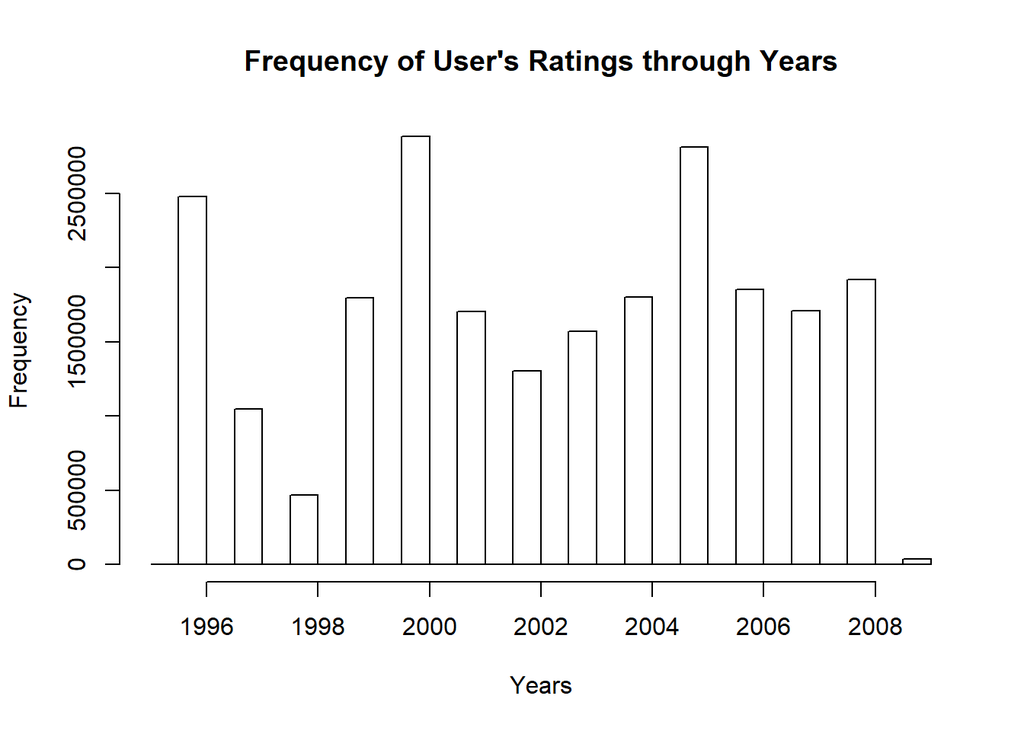

### Numbers of Ratings per Movie

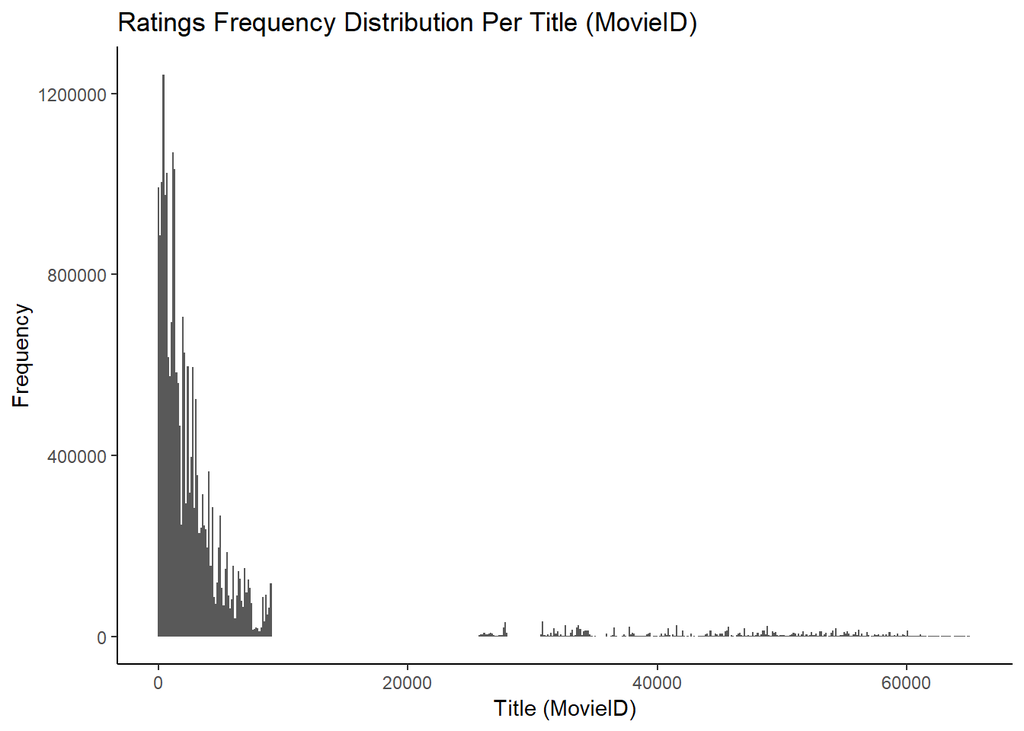

### Top Rated Movies

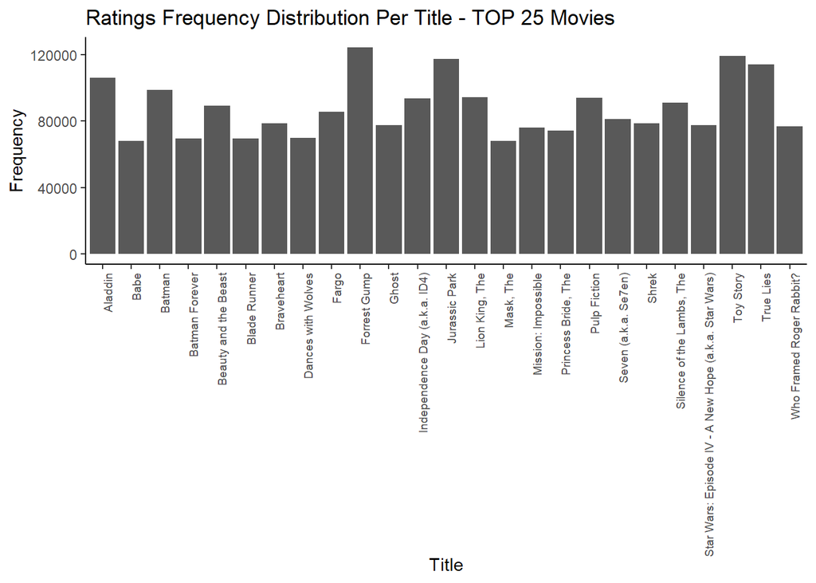

| title | count |
| --- | --- |
| Forrest Gump | 124304 |
| Toy Story | 119130 |
| Jurassic Park | 117164 |
| True Lies | 113930 |
| Aladdin | 106070 |
| Batman | 98656 |
| Lion King, The | 94435 |
| Pulp Fiction | 94008 |
| Independence Day (a.k.a. ID4) | 93440 |
| Silence of the Lambs, The | 90840 |
| Beauty and the Beast | 89315 |
| Fargo | 85480 |
| Seven (a.k.a. Se7en) | 81084 |
| Braveheart | 78774 |
| Shrek | 78564 |
| Star Wars: Episode IV - A New Hope (a.k.a. Star Wars) | 77427 |
| Ghost | 77335 |
| Who Framed Roger Rabbit? | 76825 |
| Mission: Impossible | 75876 |
| Princess Bride, The | 74045 |
| Dances with Wolves | 69936 |
| Blade Runner | 69615 |
| Batman Forever | 69432 |
| Mask, The | 68200 |
| Babe | 68140 |

### Mean Distribution per Title (Movie ID)

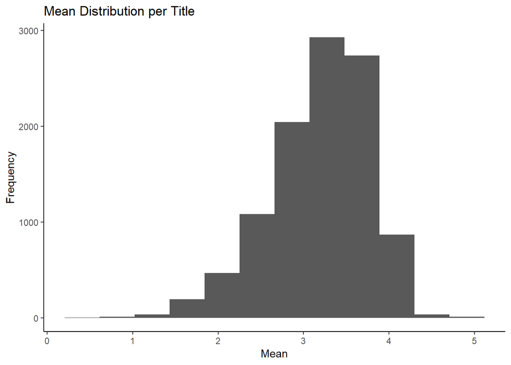

| title | mean |
| --- | --- |
| Blue Light, The (Das Blaue Licht) | 5.000000 |
| Constantine’s Sword | 5.000000 |
| Fighting Elegy (Kenka erejii) | 5.000000 |
| Hellhounds on My Trail | 5.000000 |
| Satan’s Tango (Sátántangó) | 5.000000 |
| Shadows of Forgotten Ancestors | 5.000000 |
| Sun Alley (Sonnenallee) | 5.000000 |
| Human Condition II, The (Ningen no joken II) | 4.833333 |
| Human Condition III, The (Ningen no joken III) | 4.750000 |
| Who’s Singin’ Over There? (a.k.a. Who Sings Over There) (Ko to tamo peva) | 4.750000 |
| Class, The (Entre les Murs) | 4.666667 |
| I’m Starting From Three (Ricomincio da Tre) | 4.666667 |
| Man Who Planted Trees, The (Homme qui plantait des arbres, L’) | 4.571429 |
| Bad Blood (Mauvais sang) | 4.500000 |
| Caótica Ana | 4.500000 |
| Demon Lover Diary | 4.500000 |
| End of Summer, The (Kohayagawa-ke no aki) | 4.500000 |
| Fires on the Plain (Nobi) | 4.500000 |
| Ladrones | 4.500000 |
| Life of Oharu, The (Saikaku ichidai onna) | 4.500000 |
| Man Named Pearl, A | 4.500000 |
| Mickey | 4.500000 |
| Please Vote for Me | 4.500000 |
| Power of Nightmares: The Rise of the Politics of Fear, The | 4.500000 |
| Testament of Orpheus, The (Testament d’Orphée) | 4.500000 |

### Median Distribution per Title (Movie ID)

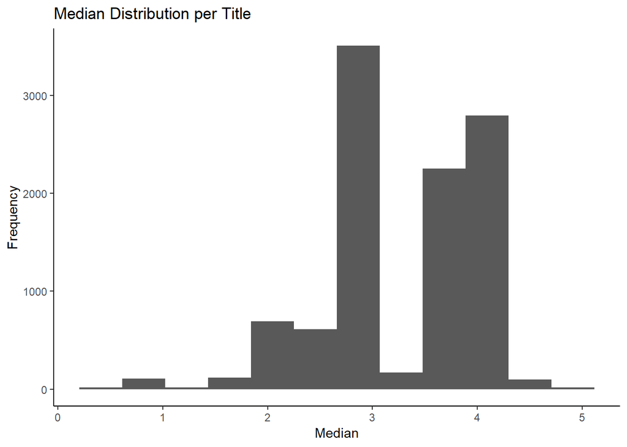

| title | median |
| --- | --- |
| Aerial, The (La Antena) | 5.00 |
| Blue Light, The (Das Blaue Licht) | 5.00 |
| Class, The (Entre les Murs) | 5.00 |
| Constantine’s Sword | 5.00 |
| Fighting Elegy (Kenka erejii) | 5.00 |
| Godfather, The | 5.00 |
| Hellhounds on My Trail | 5.00 |
| Human Condition II, The (Ningen no joken II) | 5.00 |
| Jesus | 5.00 |
| Kids of Survival | 5.00 |
| Man Who Planted Trees, The (Homme qui plantait des arbres, L’) | 5.00 |
| Parallel Sons | 5.00 |
| Satan’s Tango (Sátántangó) | 5.00 |
| Shadows of Forgotten Ancestors | 5.00 |
| Shawshank Redemption, The | 5.00 |
| Sun Alley (Sonnenallee) | 5.00 |
| Who’s Singin’ Over There? (a.k.a. Who Sings Over There) (Ko to tamo peva) | 5.00 |
| World of Apu, The (Apur Sansar) | 5.00 |
| Human Condition III, The (Ningen no joken III) | 4.75 |
| 400 Blows, The (Les Quatre cents coups) | 4.50 |
| 49 Up | 4.50 |
| Amelie (Fabuleux destin d’Amélie Poulain, Le) | 4.50 |
| American Beauty | 4.50 |
| Andrei Rublev (Andrey Rublyov) | 4.50 |
| Bad Blood (Mauvais sang) | 4.50 |

## Genre Analysis

### Rating Distribution per Genre

**Overview of Rating distribution over Genre**

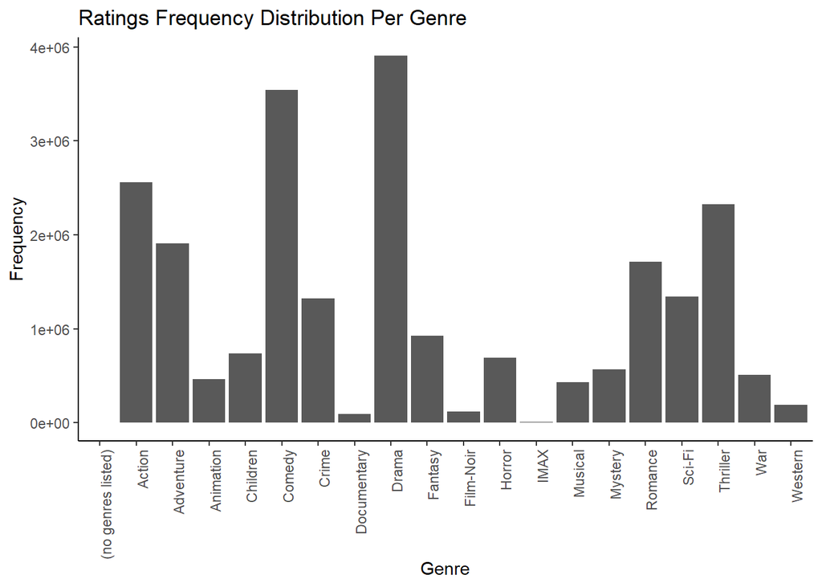

| genre | count |
| --- | --- |
| Drama | 3909401 |
| Comedy | 3541284 |
| Action | 2560649 |
| Thriller | 2325349 |
| Adventure | 1908692 |
| Romance | 1712232 |
| Sci-Fi | 1341750 |
| Crime | 1326917 |
| Fantasy | 925624 |
| Children | 737851 |
| Horror | 691407 |
| Mystery | 567865 |
| War | 511330 |
| Animation | 467220 |
| Musical | 432960 |
| Western | 189234 |
| Film-Noir | 118394 |
| Documentary | 93252 |
| IMAX | 8190 |
| (no genres listed) | 6 |

### Mean Distribution per Genre

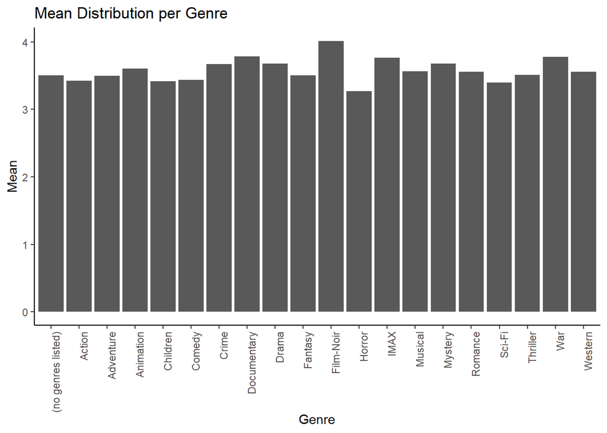

| genre | mean |
| --- | --- |
| Film-Noir | 4.011732 |
| Documentary | 3.784385 |
| War | 3.779457 |
| IMAX | 3.761844 |
| Mystery | 3.677412 |
| Drama | 3.673047 |
| Crime | 3.666151 |
| Animation | 3.599588 |
| Musical | 3.562761 |
| Western | 3.555122 |
| Romance | 3.553594 |
| Thriller | 3.506879 |
| Fantasy | 3.502419 |
| (no genres listed) | 3.500000 |
| Adventure | 3.494076 |
| Comedy | 3.437040 |
| Action | 3.421589 |
| Children | 3.418673 |
| Sci-Fi | 3.396756 |
| Horror | 3.269523 |

### Median Distribution per Genre

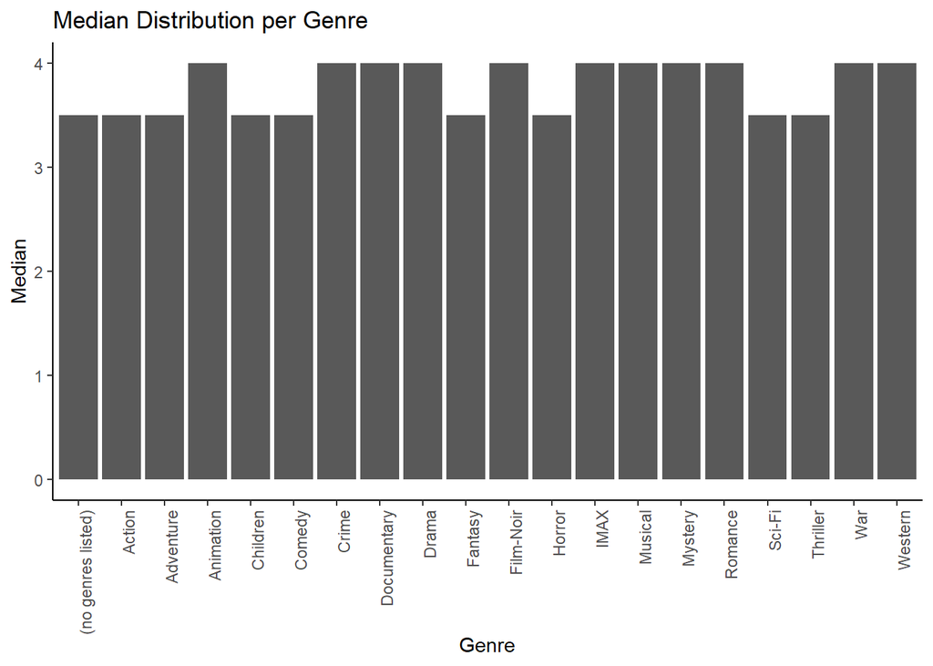

| genre | median |
| --- | --- |
| Animation | 4.0 |
| Crime | 4.0 |
| Documentary | 4.0 |
| Drama | 4.0 |
| Film-Noir | 4.0 |
| IMAX | 4.0 |
| Musical | 4.0 |
| Mystery | 4.0 |
| Romance | 4.0 |
| War | 4.0 |
| Western | 4.0 |
| (no genres listed) | 3.5 |
| Action | 3.5 |
| Adventure | 3.5 |
| Children | 3.5 |
| Comedy | 3.5 |
| Fantasy | 3.5 |
| Horror | 3.5 |
| Sci-Fi | 3.5 |
| Thriller | 3.5 |

# Analysis - Model Building and Evaluation

## Naive Baseline Model

The simplest model that someone can build, is a Naive Model that predict ALWAYS the mean. In this case, the mean is approximately 3.5.

```
## [1] "The mean is: 3.52700364195256"
```

### Naive Mean-Baseline Model

The formula used is:

$$Y_{u,i} = \hat{\mu} + \varepsilon_{u,i}$$

With $\hat{\mu}$ is the mean and $\varepsilon_{i,u}$ is the independent errors sampled from the same distribution centered at 0.

The RMSE on the `validation` dataset is **1.05**. It is very far for the target RMSE (below 0.87) and that indicates poor performance for the model.

## Movie-Based Model, a Content-based Approach

The first Non-Naive Model takes into account the content. In this case the movies that are rated higher or lower resperct to each other.

The formula used is:

$$Y_{u,i} = \hat{\mu} + b_i + \epsilon_{u,i}$$

With $\hat{\mu}$ is the mean and $\varepsilon_{i,u}$ is the independent errors sampled from the same distribution centered at 0. The $b_i$ is a measure for the popularity of movie $i$, i.e. the bias of movie $i$.

The RMSE on the `validation` dataset is **0.94**. It better than the Naive Mean-Baseline Model, but it is also very far from the target RMSE (below 0.87) and that indicates poor performance for the model.

## Movie + User Model, a User-based approach

The second Non-Naive Model consider that the users have different tastes and rate differently.

The formula used is:

$$Y_{u,i} = \hat{\mu} + b_i + b_u + \epsilon_{u,i}$$

With $\hat{\mu}$ is the mean and $\varepsilon_{i,u}$ is the independent errors sampled from the same distribution centered at 0. The $b_i$ is a measure for the popularity of movie $i$, i.e. the bias of movie $i$. The $b_u$ is a measure for the mildness of user $u$, i.e. the bias of user $u$.

The RMSE on the `validation` dataset is **0.8635** and this is very good. The Movie+User Based Model reaches the desidered performance but applying the regularization techniques, can improve the performance just a little.

## Movie + User + Genre Model, the Genre Popularity

The formula used is:

$$Y_{u,i} = \hat{\mu} + b_i + b_u + b_{u,g} + \epsilon_{u,i}$$

With $\hat{\mu}$ is the mean and $\varepsilon_{i,u}$ is the independent errors sampled from the same distribution centered at 0. The $b_i$ is a measure for the popularity of movie $i$, i.e. the bias of movie $i$. The $b_u$ is a measure for the mildness of user $u$, i.e. the bias of user $u$. The $b_{u,g}$ is a measure for how much a user $u$ likes the genre $g$.

The RMSE on the `validation` dataset is **0.8634** and this is very good. The Movie+User+Genre Based Model reaches the desidered performance but adding the `genre` predictor, doesn’t improve significantly the model’s performance. Applying the regularization techniques, can improve the performance just a little.

## Regularization

The regularization method allows us to add a penalty $\lambda$ (lambda) to penalizes movies with large estimates from a small sample size. In order to optimize $b_i$, it necessary to use this equation:

$$\frac{1}{N} \sum_{u,i} (y_{u,i} - \mu - b_{i})^{2} + \lambda \sum_{i} b_{i}^2$$

reduced to this equation:

$$\hat{b_{i}} (\lambda) = \frac{1}{\lambda + n_{i}} \sum_{u=1}^{n_{i}} (Y_{u,i} - \hat{\mu})$$

### Regularized Movie-Based Model

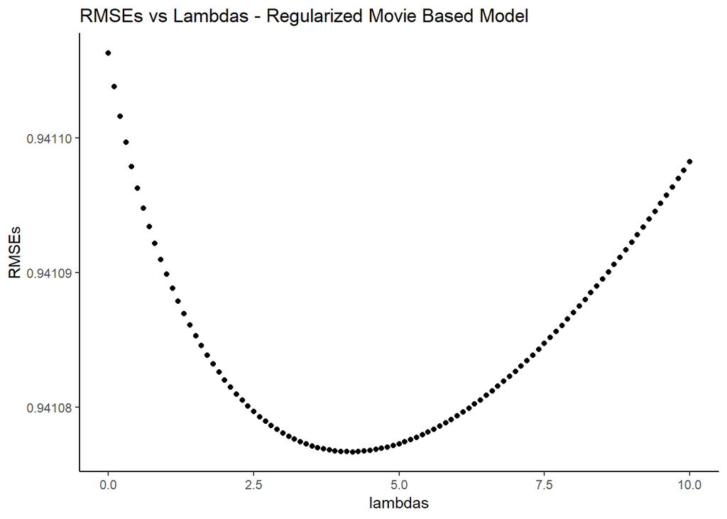

### Regularized Movie+User Model

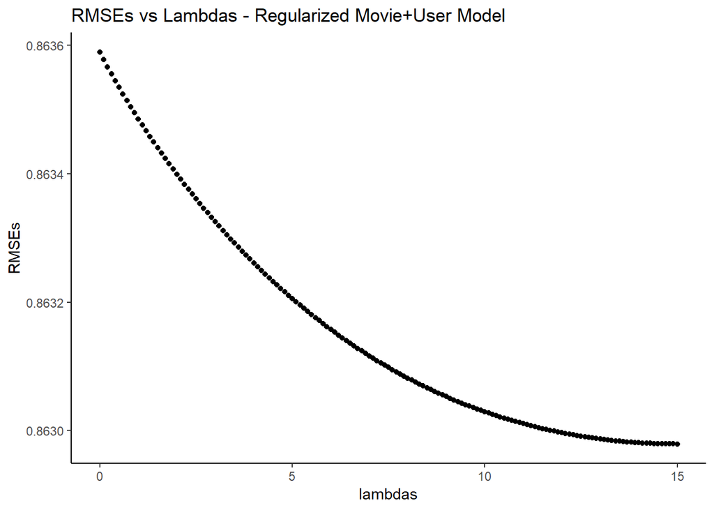

The RMSE on the `validation` dataset is **0.8629**. The Regularized Movie+User Based Model improves just a little the result of the Non-Regularized Model.

### Regularized Movie+User+Genre Model

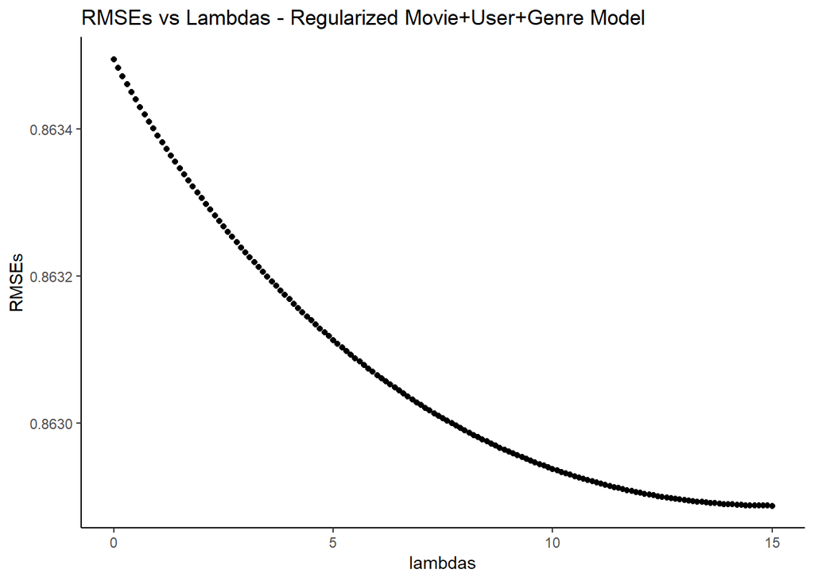

The RMSE on the `validation` dataset is **0.8628** and this is the best result of the builted models. The Regularized Movie+User+Genre Based Model improves just a little the result of the Non-Regularized Model. As the Non-Regularized Model, the `genre` predictor doesn’t improve significantly the model’s performance.

# Results

This is the summary results for all the model builted, trained on `edx` dataset and validated on the `validation` dataset.

| model | RMSE |
| --- | --- |
| Naive Mean-Baseline Model | 1.0524433 |
| Movie-Based Model | 0.9411063 |
| Movie+User Based Model | 0.8635899 |
| Movie+User+Genre Based Model | 0.8634946 |
| Regularized Movie-Based Model | 0.9410767 |
| Regularized Movie+User Based Model | 0.8629791 |
| Regularized Movie+User+Genre Based Model | 0.8628874 |

# Conclusion

After training different models, it’s very clear that `movieId` and `userId` contribute more than the `genre` predictor. Without regularization, the model can archieves and overtakes the desidered peformance, but the best is the enemy of the good and applying regularization and adding the `genre` predictor, it make possible to reach a RSME of **0.8628** that is the best result for the trained models.

# Appendix

## 1a - Initial Code privided by edX

```
#############################################################
# Create edx set, validation set, and submission file
#############################################################

# Note: this process could take a couple of minutes

if(!require(tidyverse)) install.packages("tidyverse", repos = "http://cran.us.r-project.org")
if(!require(caret)) install.packages("caret", repos = "http://cran.us.r-project.org")

# MovieLens 10M dataset:
# https://grouplens.org/datasets/movielens/10m/
# http://files.grouplens.org/datasets/movielens/ml-10m.zip

dl <- tempfile()
download.file("http://files.grouplens.org/datasets/movielens/ml-10m.zip", dl)

ratings <- read.table(text = gsub("::", "\t", readLines(unzip(dl, "ml-10M100K/ratings.dat"))),
                      col.names = c("userId", "movieId", "rating", "timestamp"))

movies <- str_split_fixed(readLines(unzip(dl, "ml-10M100K/movies.dat")), "\\::", 3)
colnames(movies) <- c("movieId", "title", "genres")
movies <- as.data.frame(movies) %>% mutate(movieId = as.numeric(levels(movieId))[movieId],
                                           title = as.character(title),
                                           genres = as.character(genres))

movielens <- left_join(ratings, movies, by = "movieId")

# Validation set will be 10% of MovieLens data

set.seed(1)
test_index <- createDataPartition(y = movielens$rating, times = 1, p = 0.1, list = FALSE)
edx <- movielens[-test_index,]
temp <- movielens[test_index,]

# Make sure userId and movieId in validation set are also in edx set

validation <- temp %>%
  semi_join(edx, by = "movieId") %>%
  semi_join(edx, by = "userId")

# Add rows removed from validation set back into edx set

removed <- anti_join(temp, validation)
edx <- rbind(edx, removed)

rm(dl, ratings, movies, test_index, temp, movielens, removed)
write.csv(edx, "edx.csv")
```

## 1b - Code used in this report - MovieLens Project.R

```
# Install all needed libraries if it is not present

if(!require(tidyverse)) install.packages("tidyverse")
if(!require(kableExtra)) install.packages("kableExtra")
if(!require(tidyr)) install.packages("tidyr")
if(!require(tidyverse)) install.packages("tidyverse")
if(!require(stringr)) install.packages("stringr")
if(!require(forcats)) install.packages("forcats")
if(!require(ggplot2)) install.packages("ggplot2")

# Loading all needed libraries

library(dplyr)
library(tidyverse)
library(kableExtra)
library(tidyr)
library(stringr)
library(forcats)
library(ggplot2)

# The RMSE function that will be used in this project is:
RMSE <- function(true_ratings = NULL, predicted_ratings = NULL) {
    sqrt(mean((true_ratings - predicted_ratings)^2))
}

# Convert timestamp to a human readable date

edx$date <- as.POSIXct(edx$timestamp, origin="1970-01-01")
validation$date <- as.POSIXct(validation$timestamp, origin="1970-01-01")

# Extract the year and month of rate in both dataset

edx$yearOfRate <- format(edx$date,"%Y")
edx$monthOfRate <- format(edx$date,"%m")

validation$yearOfRate <- format(validation$date,"%Y")
validation$monthOfRate <- format(validation$date,"%m")

# Extract the year of release for each movie in both dataset
# edx dataset
```

[output cut: 255 more lines]

```

   return(RMSE(validation$rating, predicted_ratings))
})

# Get the lambda value that minimize the RMSE

min_lambda <- lambdas[which.min(rmses)]

# Predict the RMSE on the validation set

rmse_regularized_movie_user_genre_model <- min(rmses)

# Adding the results to the results dataset

results <- results %>% add_row(model="Regularized Movie+User+Genre Based Model", RMSE=rmse_regularized_movie_user_genre_model)
```

## 1c - Enviroment

```r
print("Operating System:")
```

```
## [1] "Operating System:"
```

```r
version
```

```
##                _
## platform       x86_64-w64-mingw32
## arch           x86_64
## os             mingw32
## system         x86_64, mingw32
## status
## major          3
## minor          6.0
## year           2019
## month          04
## day            26
## svn rev        76424
## language       R
## version.string R version 3.6.0 (2019-04-26)
## nickname       Planting of a Tree
```

```r
print("All installed packages")
```

```
## [1] "All installed packages"
```

```r
installed.packages()
```

[output not shown]

[output cut: 1255 more lines]

[output not shown]